# 時系列データ分析について

#### 相関関係を確認

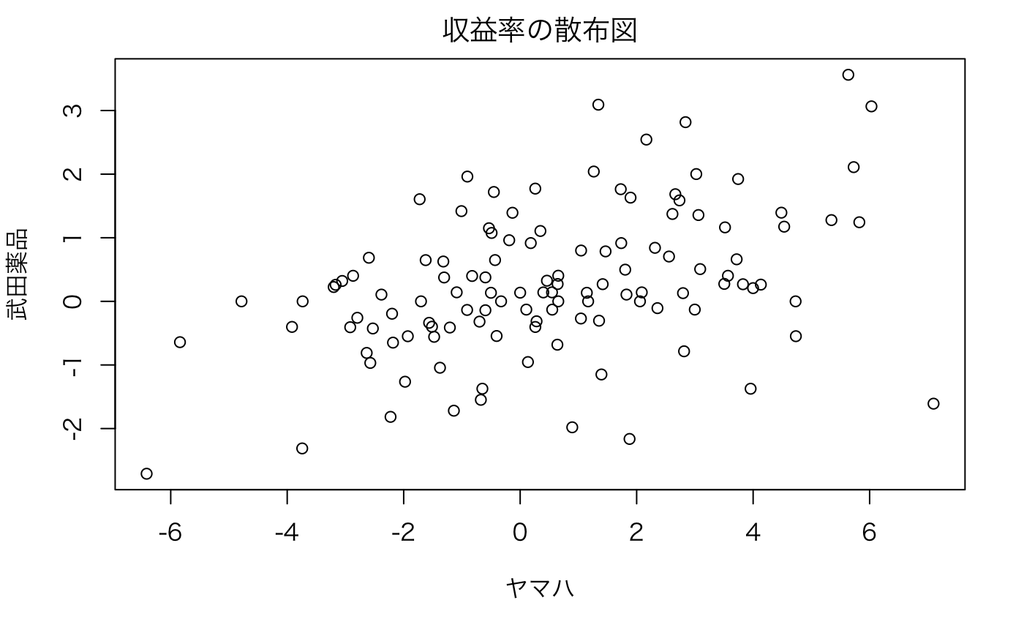

```r
par(family = "HiraKakuProN-W3")
plot(x = x7272, y = x4502, xlab="ヤマハ", ylab="武田薬品", main="収益率の散布図")
```

```r
cor(return4$x7272, return4$x4502)
```

```
[1] 0.4145996
```

散布図行列

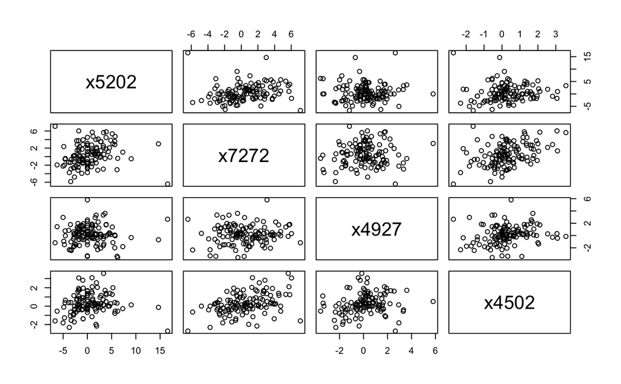

```r
plot(return4)
```

相関係数行列

```r
cor(return4)
```

```
            x5202      x7272       x4927      x4502
x5202 1.000000000 0.17962356 0.004769787 0.06021318
x7272 0.179623562 1.00000000 0.072822677 0.41459959
x4927 0.004769787 0.07282268 1.000000000 0.17598880
x4502 0.060213180 0.41459959 0.175988805 1.00000000
```

```r
detach(return4)
```

## 2-3 統計的仮説検定について

データ分析の前提条件 - データが正規分布に従う - データが独立な標本である

#### ShapiroWilkの検定

データが正規分布に従っているかの検定

```r
# 旭硝子
shapiro.test(return4$x5202) # 有意水準10%のとき棄却
```

```
    Shapiro-Wilk normality test

data:  return4$x5202
W = 0.92408, p-value = 4.19e-06
```

```r
# ヤマハ
shapiro.test(return4$x7272)
```

```
    Shapiro-Wilk normality test

data:  return4$x7272
W = 0.99498, p-value = 0.9483
```

```r
# ポーラHD
shapiro.test(return4$x4927)
```

```
    Shapiro-Wilk normality test

data:  return4$x4927
W = 0.98323, p-value = 0.1419
```

```r
# 武田薬品
shapiro.test(return4$x4502)
```

```
    Shapiro-Wilk normality test

data:  return4$x4502
W = 0.9846, p-value = 0.1893
```

#### 連の検定（runstest）

2値のデータの並びについて規則性の有無を確かめる（独立かどうかを調べる）検定 収益率が平均を下回るか否かについて規則性があるか？

```r
library(tseries) # runs.testのライブラリ
```

```r
# ２値データに変換
# 旭硝子
tmp <- as.factor(return4$x5202 < mean(return4$x5202))
runs.test(tmp)
```

```
    Runs Test

data:  tmp
Standard Normal = -1.3706, p-value = 0.1705
alternative hypothesis: two.sided
```

```r
# ヤマハ
tmp <- as.factor(return4$x7272 < mean(return4$x7272))
runs.test(tmp)
```

```
    Runs Test

data:  tmp
Standard Normal = -0.17132, p-value = 0.864
alternative hypothesis: two.sided
```

```r
# ポーラHD
tmp <- as.factor(return4$x4927 < mean(return4$x4927)) # 有意水準10%で独立ではない
runs.test(tmp)
```

```
    Runs Test

data:  tmp
Standard Normal = 1.6501, p-value = 0.09892
alternative hypothesis: two.sided
```

```r
# 武田薬品
tmp <- as.factor(return4$x4502 < mean(return4$x4502))
runs.test(tmp)
```

```
    Runs Test

data:  tmp
Standard Normal = -0.12194, p-value = 0.9029
alternative hypothesis: two.sided
```

## 2-4 時間依存の発見

- 収益率が同じような値を続けて取るような状況 ＝ 独立性を疑うべき
- データの確認

```r
par(mfcol=c(2, 2))
plot(X.price, type = "l")
plot(X.return, type = "l")
```

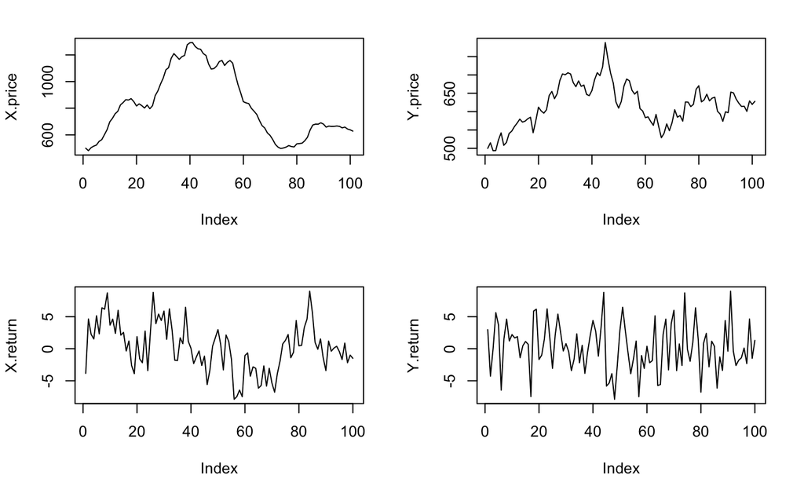

```r
plot(Y.price, type="l")
plot(Y.return, type="l")
```

- 収益率の挙動を深く読み取る

```r
# price上昇（下落）傾向　＝　return上昇（下落）傾向
par(mfcol=c(2, 1))
plot(X.price, type = "l")
plot(X.return, type = "l")
```

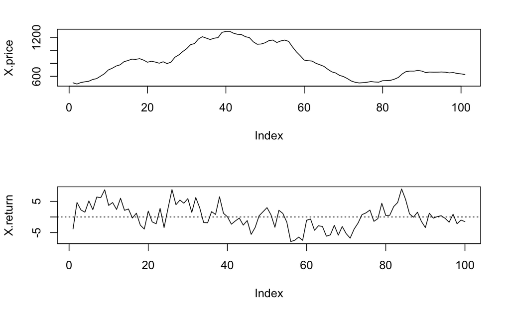

```r
abline(h = 0, lty = 3) # ドット線分
```

```r
# 傾向は観測されない
par(mfcol=c(2, 1))
plot(Y.price, type = "l")
plot(Y.return, type = "l")
```

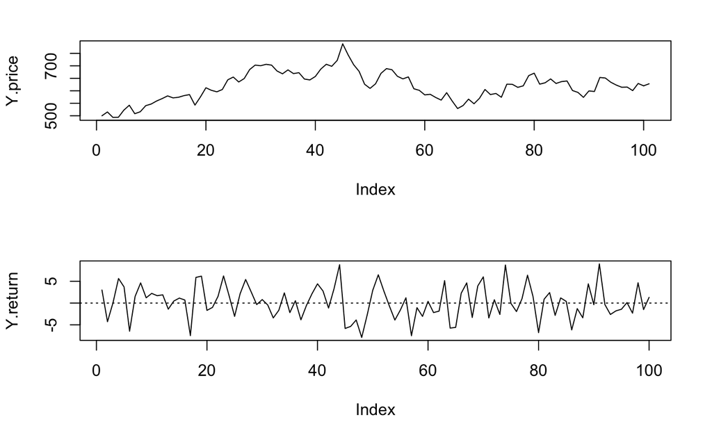

```r
abline(h = 0, lty = 3) # ドット線分
```

- XとYの平均と標準偏差

```r
print("X.return")
```

```
[1] "X.return"
```

```r
mean(X.return)
```

```
[1] 0.2280292
```

```r
sd(X.return)
```

```
[1] 3.784666
```

```r
print("Y.return")
```

```
[1] "Y.return"
```

```r
mean(Y.return)
```

```
[1] 0.2280292
```

```r
sd(Y.return)
```

```
[1] 3.784666
```

- XとYのヒストグラム

```r
par(mfcol=c(2,2))
hist(X.return)
hist(Y.return)
```

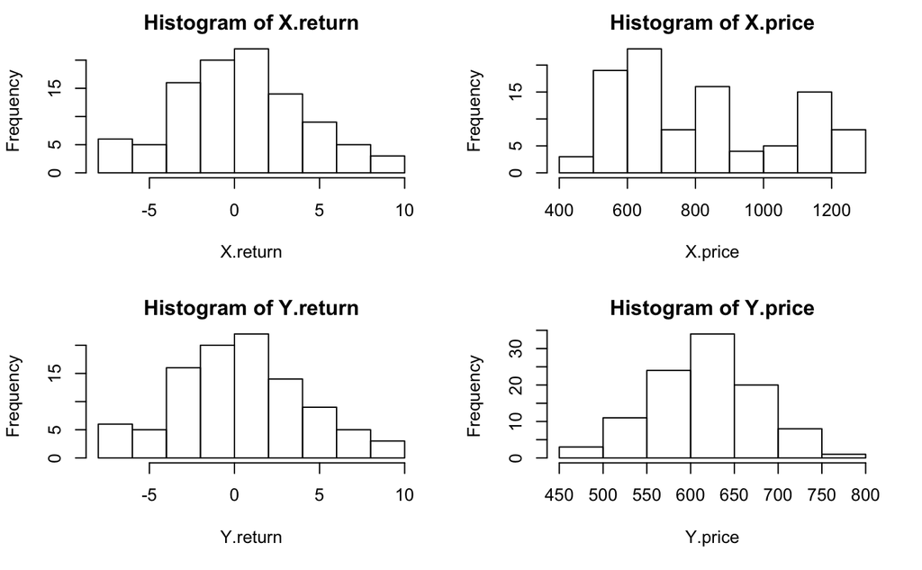

```r
hist(X.price)
hist(Y.price)
```

#### 結論

- XとYは時系列プロットだと差があるのに、ヒストグラム（独立に抽出された標本を前提）では差が現れない

# Chapter3 時系列データの時間依存と自己回帰モデル

## 3-1 時間依存の表現

```r
par(family = "HiraKakuProN-W3", mfcol=c(1, 2))
plot(x=X.return[1:99], y=X.return[2:100])
title("縦軸にrt、横軸にrt－1とした散布図")
```

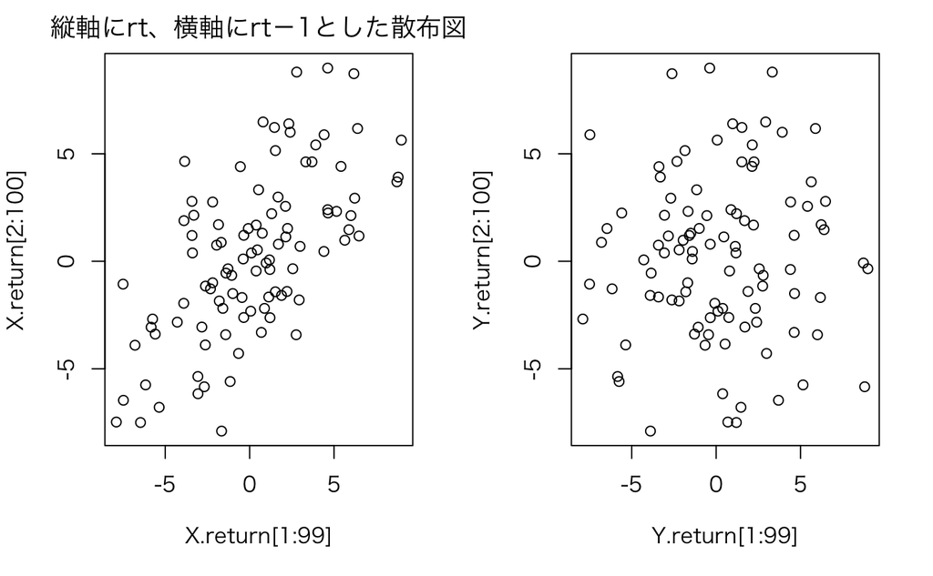

```r
plot(x=Y.return[1:99], y=Y.return[2:100])
```

- 自己相関係数  
  時間差を考慮した自分自身との相関関係
- ラグ１の自己相関係数

```r
print("Xの自己相関係数")
```

```
[1] "Xの自己相関係数"
```

```r
cor(X.return[1:99], X.return[2:100])
```

```
[1] 0.6353702
```

```r
print("Yの自己相関係数")
```

```
[1] "Yの自己相関係数"
```

```r
cor(Y.return[1:99], Y.return[2:100])
```

```
[1] 0.02348286
```

#### コレログラム

- ラグが0から20までの自己相関係数

```r
acf(X.return, plot = F)
```

```
Autocorrelations of series ‘X.return’, by lag

     0      1      2      3      4      5      6      7      8      9     10     11     12     13     14     15
 1.000  0.631  0.517  0.450  0.324  0.295  0.286  0.156  0.059  0.103  0.134  0.074  0.116  0.052 -0.087  0.020
    16     17     18     19     20
-0.032 -0.014  0.027 -0.005 -0.020
```

- コレログラム

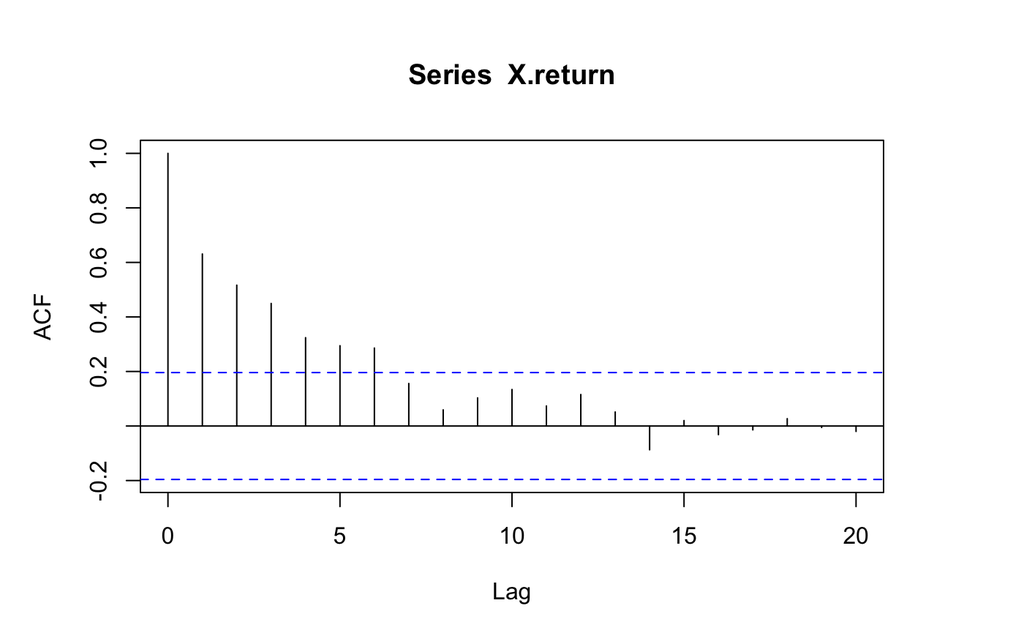

```r
# 点線は自己相関係数が0である帰無仮説のもとでの95%信頼区間
# 累積の相関関係であることに注意（6日前の収益率が当日の収益率に関係しているとはいえない）
par(mai=c(1, 1, 1, 1))
acf(X.return)
```

- 偏自己相関係数  
  ラグ0と比較した、スタートをそろえた相関

```r
acf(X.return, plot=F, type="p")
```

```
Partial autocorrelations of series ‘X.return’, by lag

     1      2      3      4      5      6      7      8      9     10     11     12     13     14     15     16
 0.631  0.197  0.110 -0.063  0.061  0.079 -0.145 -0.129  0.134  0.148 -0.103  0.038 -0.045 -0.199  0.142 -0.078
    17     18     19     20
 0.106  0.047 -0.035  0.009
```

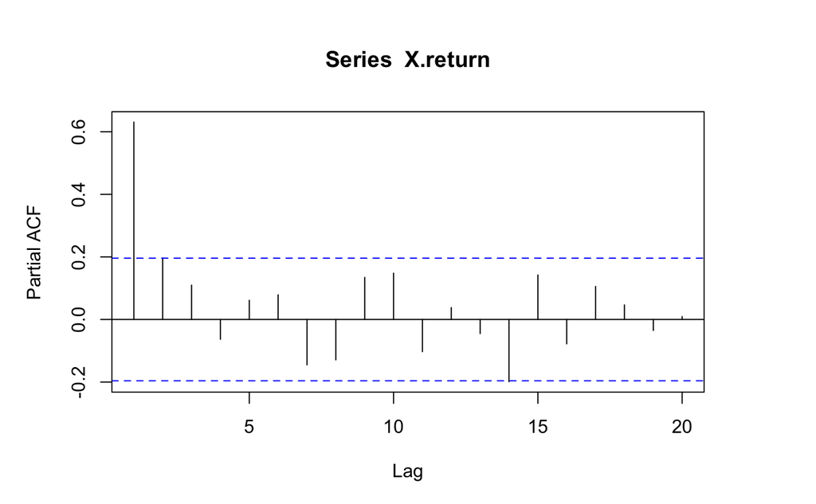

```r
par(mai=c(1, 1, 1, 1))
acf(X.return,plot=T,type="p")
```

#### がLjungBox検定

- LjungBox検定  
  帰無仮説は「自己相関関係を有していない」

```r
# p値が低いので自己相関関係を有していると判断（帰無仮説が棄却され、対立仮説が採用される）
Box.test(X.return, type="L")
```

```
    Box-Ljung test

data:  X.return
X-squared = 41.02, df = 1, p-value = 1.507e-10
```

```r
# p値が高いので自己相関関係を有していない判断（帰無仮説を受容）
Box.test(Y.return, type="L")
```

```
    Box-Ljung test

data:  Y.return
X-squared = 0.056563, df = 1, p-value = 0.812
```

## 3-2 時系列データの性質 〜定常性について〜